# CAN7035 Machine Learning and AI Assignment LAQ1

Ka Yi Chan

2026-04-15

LAQ 1 (27 marks in total): All the data required for this LAQ are in ‘For_LAQ1_required_data.zip’

You will be asked to build a random forest model that can predict whether DLBCL samples are Activated B Cell Like (ABC) or Germinal Centre B Cell Like (GCB). You have been provided with two cohorts “DLBCL_cohort_2”, comprising expression data from 350 DLBCL samples (167 ABC, 183 GCB), and “DLBCL_Cohort_1”, comprising expression data from 798 DLBCL samples (due to its size, this cohort has been split into four .rds objects). Use Cohort 2 to train, build and refine the model, and Cohort 1 to validate the model (Q4).

Submit your code and answers together as an R notebook html file (.html) with all code run and the requested output visible. Discussion of your methods and results should be given in the space between code chunks. If your chunk outputs a large amount of data (e.g. all genes in a cohort) restrict this to just a small selection of them (i.e. top 5/10 rows/columns), use the built-in data.frame functionality or rework your output into an appropriate plot. NB don’t copy paste your code and output into word.

```r
# Load packages
library(tidyverse)
library(randomForest)
library(pamr)
library(glmnet)
library(Biobase)
library(caret)
library(survival)
library(survminer)
```

```r
library(survivalROC)
library(pheatmap)
packages<- c("tidyverse", "randomForest", "pamr", "glmnet", "Biobase",
           "caret", "survival", "survminer", "survivalROC", "pheatmap")


# Load or install these packages
#for ( package in packages ) {
 #  if (! suppressPackageStartupMessages(require(package, character.only = TRUE)) ) {
  #      BiocManager::install(package,update = FALSE)
   #    suppressPackageStartupMessages(require(package, character.only = TRUE))
   #}
#}
```

```r
## Load the DLBCL cohort_2
setwd('/Users/kayivionachan/Documents/CAN7035 Machine Learning AI/CAN7035 Assignment/LAQ1/DLBCL_cohort_2')

cohort_2 <- readRDS("DLBCL.cohort.2.rds")
```

```r
# Inspect the metadata
head(pData(cohort_2), 5)
```

```
##           COO OS_TIME OS_IND   cohort
## GSM274895 GCB    2.68      1  Testing
## GSM274896 GCB    0.82      1 Training
## GSM274897 ABC    2.54      1 Training
## GSM274898 ABC    9.67      0 Training
## GSM274899 ABC    4.83      0  Testing
```

```r
# Check the cell of origin
table(cohort_2$COO)
```

```
##
## ABC GCB
## 167 183
```

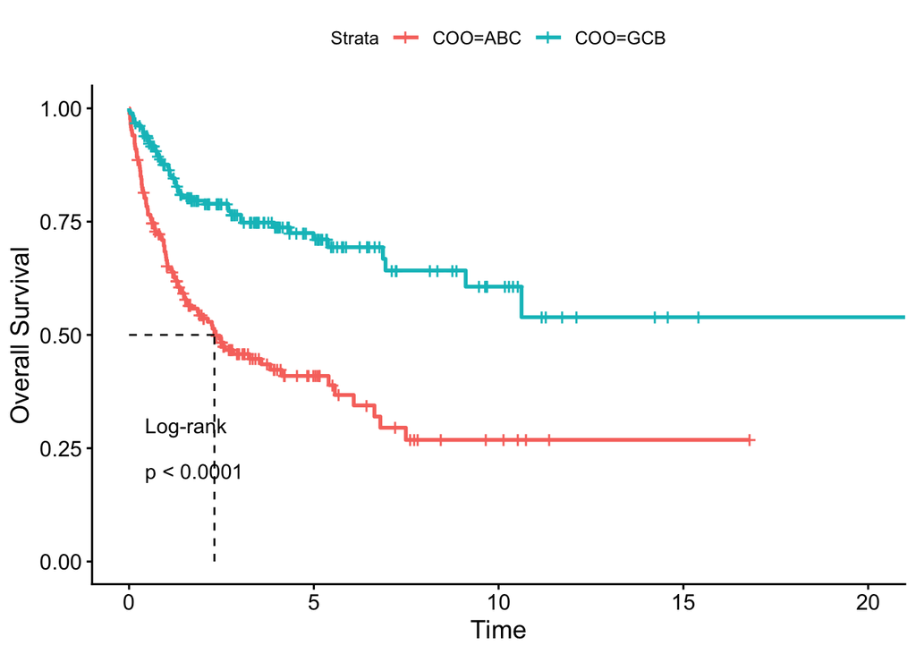

```r
# Check the survival data
ggsurvplot(survfit(Surv(OS_TIME, OS_IND) ~ COO, data = pData(cohort_2)),
                             pval = TRUE,
                             pval.method = TRUE,
                             pval.size=4,
                             surv.median.line   = "hv",
                             ylab="Overall Survival")
```

The Kaplan-Meier suvival plot shows ABC subtypes has a significantly lower overall suvival rate compared to GCB subtype with p-value < 0.0001. The big difference between these 2 subtypes help the model to distinguish them more easily.

Test/Train split

```r
# Set seed to ensure reproducibility of random split
set.seed(15)
# Generate a vector to assign samples to group 1 (Train) or 2 (Test)
train_test <- sample(
    # The group IDs to assign
    1:2,
    # Set the number of draws equal to the total number of samples in the dataset
    length(sampleNames(cohort_2)),
    # Allow repeated selection of IDs
    replace = TRUE,
    # Set split ratio to 70% Train / 30% Test
    prob = c(0.7, 0.3))
```

```r
# Check the number of samples in each cohort
table(train_test)
```

```
## train_test
##   1   2
## 238 112
```

Subset the train_test to create a training and testing. Take all the values where the train_test is 1 and assign into train, and all those where the train_test is 2 and assign into test.

```r
# For each patient if the random number is 1 assign to training
train_cohort2 <- cohort_2[,train_test == 1]
# If 2 assign to testing
test_cohort2 <- cohort_2[,train_test == 2]
# Store this in the cohort_2
cohort_2$cohort <- ifelse(train_test == 1, "Training", "Testing")
```

1. Build a random forest model that can predict cell-of-origin (COO) using the training/testing cohort (70/30 training/testing split). Tune the model to select an appropriate number of trees and mtry value to produce the lowest out of bag (OOB) error. Report the error of the model in the training and testing cohort (OOB, type I, type 2 errors and a ROC curve). Discuss how well your model works on these data. (7 marks)

To build a predictive model, here use Random Forest algorithum to classify the cell of original (COO) as either ABC or GCB. Random forest uses a single matrix where each row is a unique sample and each column is a feature (gene). In addition, en extra target column COO is required to acts as the label for Random Forest to map specific gene expression patterns to their corresponding cell types.

```r
# Create the training data frame by combining the target column COO with the feature matrix
train_cohort2.rf <- cbind(
    # Convert COO into a factor if it was character
    COO = as.factor(train_cohort2$COO),
    # Transpose the expression matrix so samples are rows and genes are columns
    exprs(train_cohort2) %>%
        t() %>% as.data.frame())

# View a small subset of the resulting data frame to verify structure
train_cohort2.rf[1:5,1:5]
```

```
##           COO    RFC2  PAX8 GUCA1A  THRA
## GSM274895 GCB  9.0025 8.621 6.5080 6.652
## GSM274896 GCB  9.8085 9.349 7.2775 7.436
## GSM274898 ABC  9.7070 8.112 5.9595 7.494
## GSM274899 ABC 10.0360 7.232 7.4705 7.321
## GSM274902 ABC  9.6465 7.468 5.3400 6.274
```

```r
# Repeat the formatting process for the testing dataset
test_cohort2.rf <- cbind(COO = as.factor(test_cohort2$COO),
      exprs(test_cohort2) %>% t() %>% as.data.frame())
```

Build a temporary model with many trees to find where the error stabilises

```r
set.seed(15)
rf_ntree <- randomForest(
    # All gene expression columns except COO are provided as predictor variables
    select(train_cohort2.rf, -COO),
    # Set target COO as response variable for the model to predict
    train_cohort2.rf$COO,
    # Try 500 tree for tuning the model
    ntree = 500)
```

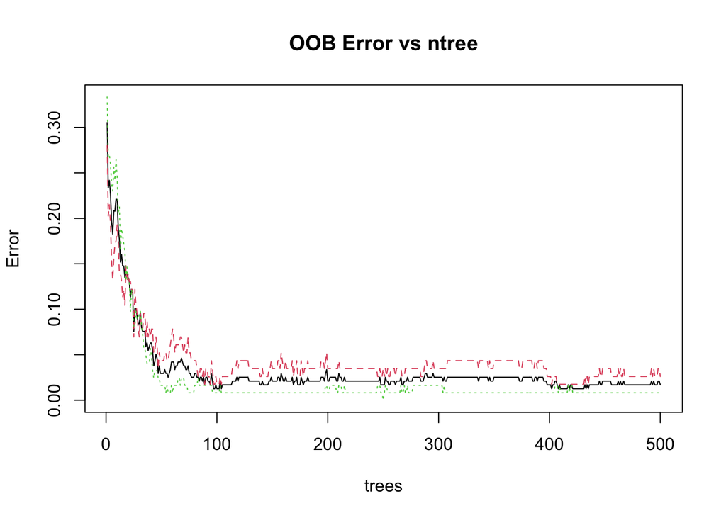

```r
# Review the tuning model, including the Out-of-Bag (OOB) error rate
plot(rf_ntree, main = "OOB Error vs ntree")
```

Interpretation of OOB Error vs ntree plot The black line represents the overall OOB error for both ABC and GCB class. Red line represents error rate of false negatives and green line represents error rate of false positive. The overall error rate is roughly 2% and all three lines dropped sharply in the first 100 trees then stabilised afterwards. It seems setting ntree = 100 would be reasonable because the OOB error plot shows that error stabilised by approximately 100 trees and by setting ntree = 100 would ensure the model to have fully converged.

Next is to tune the mtry, which is the number of features checked at each node of the trees

```
## mtry = 128  OOB error = 1.26%
## Searching left ...
## mtry = 86    OOB error = 4.62%
## -2.666667 0.01
## Searching right ...
## mtry = 192   OOB error = 2.52%
## -1 0.01
```

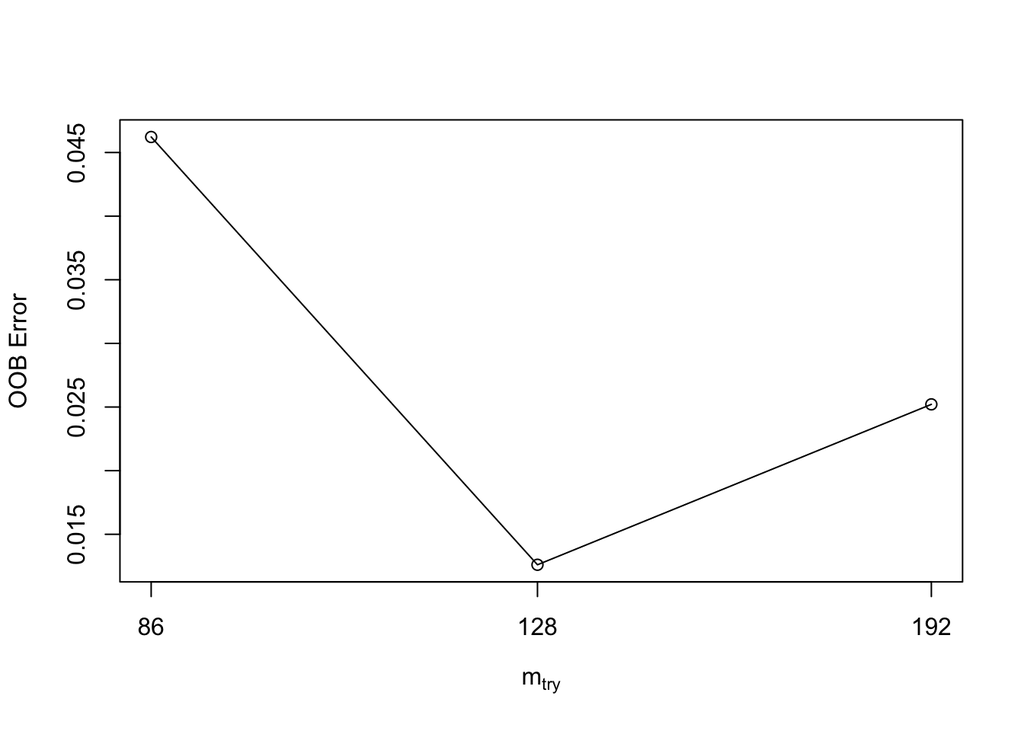

```r
# This function will try several mtry values and report the mtry values with the lowest OOB error.
set.seed(15)
mtryTune <- tuneRF(select(train_cohort2.rf, -COO),
                   train_cohort2.rf$COO,
                   stepFactor = 1.5,
                   plot = TRUE,
                   ntreeTry = 100,
                   trace = TRUE,
                   improve = 0.01)
```

Test the random forest model with pre-defined ntree = 100 and mtry = 128

```r
# Build the final tuned random forest model using optimised parameters
set.seed(15)
rf_cohort2 <- randomForest(select(train_cohort2.rf, -COO),
                    train_cohort2.rf$COO,
                    mtry = 128,
                    ntree = 100)
print(rf_cohort2)
```

```
##
## Call:
##  randomForest(x = select(train_cohort2.rf, -COO), y = train_cohort2.rf$COO,      ntree = 100, mtry = 128)
##                Type of random forest: classification
##                      Number of trees: 100
## No. of variables tried at each split: 128
##
##         OOB estimate of  error rate: 1.26%
## Confusion matrix:
##     ABC GCB class.error
## ABC 113   2 0.017391304
## GCB   1 122 0.008130081
```

Interpretation of the confusion matrix Type 1 Error (false positive) is when the model predicts the positive class ABC incorrectly as GCB. This means the model is over-estimating instances of positives when the ground truth is negative and is known as specificity. Type II Error (false negative) is when the model predicts the non-reference GCB as ABC, which means the model is under-estimating where the positives get missed out and known as sensitivity. According to the confusion matrix, there are 113 actual ABC samples are correctly predicted as ABC = true positive. There are 2 actual ABC samples were predicted as GCB = false negative There are 1 actual GCB samples were predicted as ABC = false positive There are 122 actual GCB samples were correctly predicted as GCB = true negative.

Type I Error is 0.81% because falsely calling positive. Type II Error is 1.74 % because falsely calling negative. This suggests that the model’s sensitivity and specificity very similar.

The overall OOB error rate is 1.26% meaning about 98.74% of samples were correctly classified during out of bag estimation.

Next step is validation phase where the random forest model is being tested how well it learned from the patterns.

```r
# Prediction. This function takes the trained model and applies to the training data
cohort2_p1 <- predict(
    # The trained Random Forest model object
    rf_cohort2,
    # Training cohort - The feature matrix used for the predictions
    train_cohort2.rf)

# The caret packages confusion Matrix function evaluate the model's accuracy
confusionMatrix(cohort2_p1, train_cohort2.rf$COO)
```

```
## Confusion Matrix and Statistics
##
##           Reference
## Prediction ABC GCB
##        ABC 115   0
##        GCB   0 123
##
##                Accuracy : 1
##                  95% CI : (0.9846, 1)
##     No Information Rate : 0.5168
##     P-Value [Acc > NIR] : < 2.2e-16
##
##                   Kappa : 1
##
##  Mcnemar's Test P-Value : NA
##
##             Sensitivity : 1.0000
##             Specificity : 1.0000
##          Pos Pred Value : 1.0000
##          Neg Pred Value : 1.0000
##              Prevalence : 0.4832
##          Detection Rate : 0.4832
##    Detection Prevalence : 0.4832
##       Balanced Accuracy : 1.0000
##
##        'Positive' Class : ABC
##
```

```r
# Generate the probability scores for each class instead of just the final label
# This provides a measure of the model's confidence for each prediction
cohort2_p1.prob <- predict(rf_cohort2, train_cohort2.rf, type = "prob")
```

As shown in the confusion matrix from predicting on the training data, it shows a perfect classification i.e. Accuracy = 1 (100%), Sensitivity = 1 (100%) and Specificity = 1 (100%). This is typical for random forest because the model has already seen the training data that reflects the model’s capacity to memorise the training data. Its accuracy and performance may not be as good when working on the test data.

Test the model on testing cohort

```r
## Prediction function to apply test data
cohort2_p2 <- predict(
    ## Model
    rf_cohort2,
    ## Testing cohort
    test_cohort2.rf)
## again run confusion Matrix
confusionMatrix(cohort2_p2, test_cohort2.rf$COO)
```

```
## Confusion Matrix and Statistics
##
##           Reference
## Prediction ABC GCB
##        ABC  51   1
##        GCB   1  59
##
##                Accuracy : 0.9821
##                  95% CI : (0.937, 0.9978)
##     No Information Rate : 0.5357
##     P-Value [Acc > NIR] : <2e-16
##
##                   Kappa : 0.9641
##
##  Mcnemar's Test P-Value : 1
##
##             Sensitivity : 0.9808
##             Specificity : 0.9833
##          Pos Pred Value : 0.9808
##          Neg Pred Value : 0.9833
##              Prevalence : 0.4643
##          Detection Rate : 0.4554
##    Detection Prevalence : 0.4643
##       Balanced Accuracy : 0.9821
##
##        'Positive' Class : ABC
##
```

```r
## Again get the probabilities.
cohort2_p2.prob <- predict(rf_cohort2, test_cohort2.rf, type = "prob")
```

Test the model - once the model has learned the training data, Receiver Operating Characteristic (ROC) curve is used to visualise the performance and tell us how good the model is at distinguishing between ABC and GCB. The Area Under the Curve (AUC) comes from ROC curve and it plots the true positive rate (sensitivity) against false positive (specificity). AUC score at 1 means a perfect model that will distinguish the subtypes 100% correct, whilst 0.5 means the model is not better than a random occurrence.

```r
## Evaluate the model's performance to distinguish subtypes in training data
rf.train_cohort2.predict.ROC <- pROC::roc(
    # Ground truth for classification
    train_cohort2$COO,
    # Predict probabilities for the GCB subtype from the training split
   cohort2_p1.prob[,"GCB"])
```

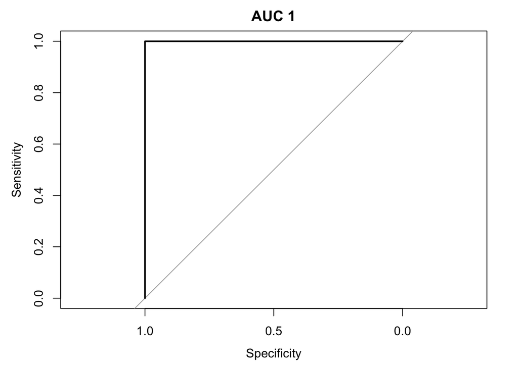

```r
plot(
    rf.train_cohort2.predict.ROC,
    main = paste("AUC", round(rf.train_cohort2.predict.ROC$auc, 5))
    )
```

```r
# Evaluate the model's true predictive power on unseen clinical samples
rf.test_cohort2.predict.ROC <- pROC::roc(
    # Provide the actual 30% testing data
    test_cohort2$COO,
    # Predict probabilities for the GCB subtype from the testing split
    cohort2_p2.prob[,"GCB"])
```

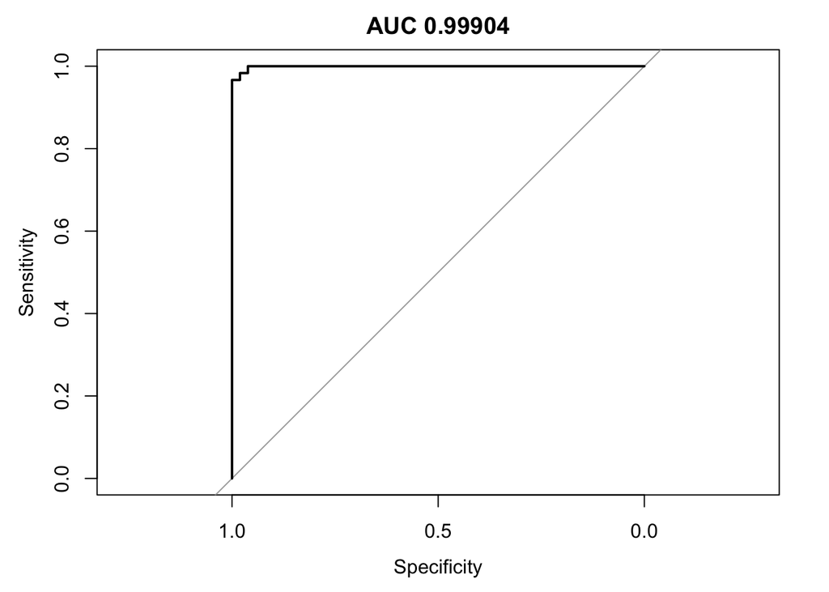

```r
plot(
    rf.test_cohort2.predict.ROC,
    main = paste("AUC", round(rf.test_cohort2.predict.ROC$auc, 5))
    )
```

The Random Forest model achieved a perfect AUC of 1.0 on the training cohort and a near-perfect AUC of 0.99904 on the independent testing cohort. This consistency confirms that the model has successfully identified the underlying biological signatures rather than simply memorizing the training samples, indicating it is highly robust and free from significant overfitting.

2. Select the 1000 most important features in the model and use these to recreate the model – Report the error of this model in the training and testing cohort (OOB, type I, type 2 errors & ROC). Discuss whether it performs better or worse than the previous model. (6 marks)

```r
# Extract the top 1000 genes ranked by importance (MeanDecreaseGini)
top1000Genes <-
    importance(rf_cohort2) %>%
    # Turn it into a data.frame
    as.data.frame() %>%
    # Order the genes in descending order
    arrange(-MeanDecreaseGini) %>%
    # Extract the rownames in order
    rownames() %>%
    # Select top 1000 genes
    .[1:1000]

# Inspect top1000Genes
head(top1000Genes, 10)
```

```
##  [1] "CYB5R2"   "RAB29"    "ASB13"    "SPRED2"   "STAG3"    "SYTL4"
##  [7] "SERPINA9" "LPP"      "LMO2"     "C12orf77"
```

Recreate the model with only these 1000 more important genes

```r
# Create new dataset containing these 1000 genes and the COO column
train_cohort2_top1000Genes.rf <- select(train_cohort2.rf, c('COO', top1000Genes))
test_cohort2_top1000Genes.rf <- select(test_cohort2.rf, c('COO', top1000Genes))

# Rebuild a random forest using top 1000 genes
set.seed(15)
rf_cohort2_top1000 <- randomForest(select(train_cohort2_top1000Genes.rf, top1000Genes),
                    train_cohort2_top1000Genes.rf$COO,
                    mtry = 128,
                    ntree = 100)
print(rf_cohort2_top1000)
```

```
##
## Call:
##  randomForest(x = select(train_cohort2_top1000Genes.rf, top1000Genes),      y = train_cohort2_top1000Genes.rf$COO, ntree = 100, mtry = 128)
##                Type of random forest: classification
##                      Number of trees: 100
## No. of variables tried at each split: 128
##
##         OOB estimate of  error rate: 1.26%
## Confusion matrix:
##     ABC GCB class.error
## ABC 114   1 0.008695652
## GCB   2 121 0.016260163
```

There are 114 actual ABC samples are correctly predicted as ABC = true positive. There are 1 actual ABC samples were predicted as GCB = false negative There are 2 actual GCB samples were predicted as ABC = false positive There are 121 actual GCB samples were correcly predicted as GCB = true negative.

The overall OOB error rate of this model remained same performance as the previous model (1.26%).

Test the top 1000 genes model

```r
# Test prediction of the top1000 genes model on the training data
cohort2_top1000_p1 <- predict(
    # Top1000 genes Random Forest model object
    rf_cohort2_top1000,
    # Top1000 genes training cohort
    train_cohort2_top1000Genes.rf)

# The caret packages confusion Matrix function evaluate the model's accuracy
confusionMatrix(cohort2_top1000_p1, train_cohort2_top1000Genes.rf$COO)
```

```
## Confusion Matrix and Statistics
##
##           Reference
## Prediction ABC GCB
##        ABC 115   0
##        GCB   0 123
##
##                Accuracy : 1
##                  95% CI : (0.9846, 1)
##     No Information Rate : 0.5168
##     P-Value [Acc > NIR] : < 2.2e-16
##
##                   Kappa : 1
##
##  Mcnemar's Test P-Value : NA
##
##             Sensitivity : 1.0000
##             Specificity : 1.0000
##          Pos Pred Value : 1.0000
##          Neg Pred Value : 1.0000
##              Prevalence : 0.4832
##          Detection Rate : 0.4832
##    Detection Prevalence : 0.4832
##       Balanced Accuracy : 1.0000
##
##        'Positive' Class : ABC
##
```

```r
# Generate the probability scores for each class instead of just the final label
# This provides a measure of the model's confidence for each prediction
cohort2_top1000_p1.prob <- predict(rf_cohort2_top1000, train_cohort2_top1000Genes.rf, type = "prob")
```

```r
# Test prediction of the top1000 genes model on the testing data
cohort2_top1000_p2 <- predict(
    # Top1000 genes Random Forest model object
    rf_cohort2_top1000,
    # Top1000 genes testing cohort
    test_cohort2_top1000Genes.rf)
# Confusion Matrix
confusionMatrix(cohort2_top1000_p2, test_cohort2_top1000Genes.rf$COO)
```

```
## Confusion Matrix and Statistics
##
##           Reference
## Prediction ABC GCB
##        ABC  52   1
##        GCB   0  59
##
##                Accuracy : 0.9911
##                  95% CI : (0.9513, 0.9998)
##     No Information Rate : 0.5357
##     P-Value [Acc > NIR] : <2e-16
##
##                   Kappa : 0.9821
##
##  Mcnemar's Test P-Value : 1
##
##             Sensitivity : 1.0000
##             Specificity : 0.9833
##          Pos Pred Value : 0.9811
##          Neg Pred Value : 1.0000
##              Prevalence : 0.4643
##          Detection Rate : 0.4643
##    Detection Prevalence : 0.4732
##       Balanced Accuracy : 0.9917
##
##        'Positive' Class : ABC
##
```

```r
# Measure the model's confidence for each prediction
cohort2_top1000_p2.prob <- predict(rf_cohort2_top1000, test_cohort2_top1000Genes.rf, type = "prob")
```

Run ROC on top 1000 gene model

```r
## Evaluate the model's performance to distinguish subtypes in training data
rf.train_cohort2_top1000.predict.ROC <- pROC::roc(
    # Ground truth for classification
    train_cohort2_top1000Genes.rf$COO,
    # Predict probabilities for the GCB subtype from the training split
    cohort2_top1000_p1.prob[,"GCB"])
```

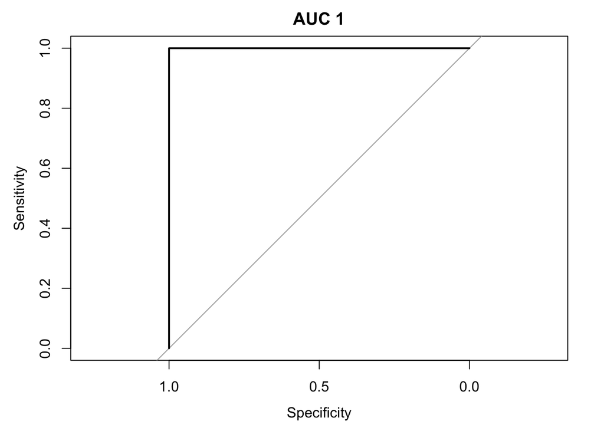

```r
plot(
    rf.train_cohort2_top1000.predict.ROC,
    main = paste("AUC", round(rf.train_cohort2_top1000.predict.ROC$auc, 5))
    )
```

```r
# Evaluate the model's true predictive power on unseen clinical samples
rf.test_cohort2_top1000.predict.ROC <- pROC::roc(
    # Provide the actual 30% testing data
    test_cohort2_top1000Genes.rf$COO,
    # Predict probabilities for the GCB subtype from the testing split
    cohort2_top1000_p2.prob[,"GCB"])
```

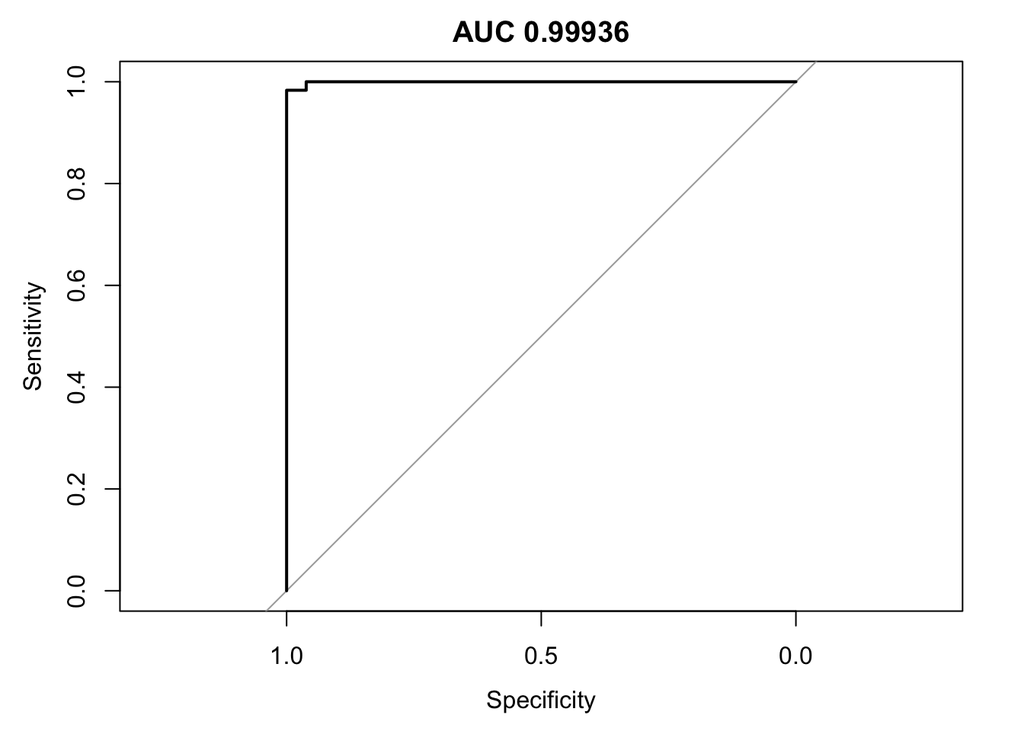

```r
plot(
    rf.test_cohort2_top1000.predict.ROC,
    main = paste("AUC", round(rf.test_cohort2_top1000.predict.ROC$auc, 5))
    )
```

3. Recursively retrain the model using the n most important features (where n is a reducing number of features) to find the optimum number of genes to include in the training. Report the error of the model in the training and testing cohort, including OOB, type I, type 2 errors & ROC. Discuss the n value chosen, explaining your strategy for gene selection and describe which of the 3 models you feel best models the data (7 marks)

For Q3, a for loop is required to test a range of the most important genes e.g. 1000, 800, 600, 400, 200, 100, 50 and 10.

```r
# Rank genes according to importance
genes_ranked <-  importance(rf_cohort2) %>%
    as.data.frame() %>%
    arrange(-MeanDecreaseGini) %>%
    rownames()

# Define the number of genes to be tested
n_genes <- c(1000, 800, 600, 400, 200, 100, 50, 10)

# For loop starts here
set.seed(15)
for (n in n_genes) {

  top_genes_rf <- randomForest(select(train_cohort2.rf, all_of(genes_ranked[1:n])),
                    train_cohort2.rf$COO,
                    mtry = floor(sqrt(n)),
                    ntree = 100)

  # OOB Errors
  oob_error <- top_genes_rf$err.rate[nrow(top_genes_rf$err.rate), "OOB"]*100
  type1_error <- top_genes_rf$confusion["GCB", "class.error"]*100
  type2_error <- top_genes_rf$confusion["ABC", "class.error"]*100

  # Test prediction and AUC
  top_genes_p2 <- predict(top_genes_rf, test_cohort2.rf, type = "prob")
  top_genes_ROC <- pROC::roc(test_cohort2$COO, top_genes_p2[, "GCB"])
  top_genes_AUC <- as.numeric(top_genes_ROC$auc)

  cat("Genes =", n,
      "| OOB =", round(oob_error, 2), "%",
      "| Type I Error =", round(type1_error, 2),"%",
      "| Type II Error =", round(type2_error, 2), "%",
     # "| Test Prediction  =", round(top_genes_p2, 2), "%",
      "| AUC =", round(top_genes_AUC, 4), "\n")

}
```

```
## Genes = 1000 | OOB = 1.68 % | Type I Error = 0.81 % | Type II Error = 2.61 % | AUC = 1
```

```
## Genes = 800 | OOB = 2.1 % | Type I Error = 2.44 % | Type II Error = 1.74 % | AUC = 1
```

```
## Genes = 600 | OOB = 1.26 % | Type I Error = 1.63 % | Type II Error = 0.87 % | AUC = 0.9994
```

```
## Genes = 400 | OOB = 1.68 % | Type I Error = 3.25 % | Type II Error = 0 % | AUC = 0.9994
```

```
## Genes = 200 | OOB = 2.52 % | Type I Error = 3.25 % | Type II Error = 1.74 % | AUC = 0.9994
```

```
## Genes = 100 | OOB = 2.52 % | Type I Error = 2.44 % | Type II Error = 2.61 % | AUC = 0.9997
```

```
## Genes = 50 | OOB = 2.94 % | Type I Error = 4.07 % | Type II Error = 1.74 % | AUC = 0.9982
```

```
## Genes = 10 | OOB = 4.2 % | Type I Error = 5.69 % | Type II Error = 2.61 % | AUC = 0.9913
```

The AUC remained almost perfect (from 1 to 0.9913) despite I dropped from 1000 genes down to 10. This suggests that the signal for distinguishing ABC from GCB is very strong in a small number of genes.

When comparing the three models: full feature set, top 1000 genes subset and the optimised 600 genes subset, I believe the 600 genes model would be the most ideal representation of the data. The reasons are that: 1) the full feature model contain redundant information which may induce noise and take up too much unnecessary computational work; 2) the 1000 genes model maintained the same performance as the full features but might still contain redundant information that could still take up unnecessary computational work and 3) the 600 genes model achieved maximum accuracy with the minimum number of features, thus it is more practical for development into a diagnostic assay than using a whole transcriptome approach.

4. Using your final optimum model, predict the cell of origin in Cohort 1 (the cohort used in the practical). Report the type 1 and type 2 errors and a ROC curve in this validation cohort. Discuss whether this model works within this validation cohort and explain your reasoning.

Define the top 600 genes

```r
top600genes <- genes_ranked[1:600]
```

Rebuild the optimal model before answering Q4

```r
set.seed(15)
optimal_model_rf <- randomForest(
  select(train_cohort2.rf, all_of(top600genes)),
  train_cohort2.rf$COO,
  ntree = 100,
  mtry = floor(sqrt(600))

)

print(optimal_model_rf)
```

```
##
## Call:
##  randomForest(x = select(train_cohort2.rf, all_of(top600genes)),      y = train_cohort2.rf$COO, ntree = 100, mtry = floor(sqrt(600)))
##                Type of random forest: classification
##                      Number of trees: 100
## No. of variables tried at each split: 24
##
##         OOB estimate of  error rate: 1.26%
## Confusion matrix:
##     ABC GCB class.error
## ABC 115   0  0.00000000
## GCB   3 120  0.02439024
```

The confusion matrix of the optimal model shows OOB error rate at 1.26%, type I error rate at 2.4% and type II error rate at 0%.

Laod Cohort 1 dataset

```r
# Load Cohort 1
setwd('/Users/kayivionachan/Documents/CAN7035 Machine Learning AI/CAN7035 Assignment/LAQ1/DLBCL_cohort_1')

cohort_1 <- Biobase::combine(readRDS("DLBCL.eSet.1.rds"),
        readRDS("DLBCL.eSet.2.rds"),
        readRDS("DLBCL.eSet.3.rds"),
        readRDS("DLBCL.eSet.4.rds"))
```

```r
# Inspect the metadata
head(pData(cohort_1), 5)
```

```
##         COO  OS_TIME OS_IND
## Sample1 ABC 3.452430      0
## Sample2 GCB 2.622861      0
## Sample3 GCB 1.136208      1
## Sample4 ABC 5.530458      0
## Sample5 GCB 5.212868      0
```

```r
# Check the cell of origin
table(cohort_1$COO)
```

```
##
## ABC GCB
## 255 543
```

Create the validation data frame for Cohort 1 and inspect its original data frame

```r
cohort1_rf <- cbind(
  COO = as.factor(cohort_1$COO),
  exprs(cohort_1) %>%
    t() %>% as.data.frame()
)

cohort1_rf[1:5, 1:5]
```

```
##         COO   EEF1A1   SLC35E2    RPS28    IPO13
## Sample1 ABC 15.02181  8.490093 14.08284 13.09516
## Sample2 GCB 14.89938  9.107928 14.46471 13.47963
## Sample3 GCB 15.21571  9.014345 14.37709 13.00497
## Sample4 ABC 14.70279 10.645180 14.77448 10.70097
## Sample5 GCB 14.88576 10.256087 14.47164 13.05381
```

Filter the data to only include the 600 genes optimal model from Q3 and inspect data frame

```r
cohort1_rf <- cohort1_rf[, c("COO", top600genes)]

cohort1_rf[1:5, 1:5]
```

```
##         COO   CYB5R2    RAB29     ASB13   SPRED2
## Sample1 ABC 12.86723 13.90787 12.352929 11.86851
## Sample2 GCB 10.65550 13.49683 13.850012 12.28397
## Sample3 GCB 10.11431 13.05999 12.986378 13.82930
## Sample4 ABC 11.61656 13.79248  9.953826 11.55487
## Sample5 GCB 10.47627 14.04379 14.279418 13.11035
```

```r
# Check if Cohort 1 contains all 600 genes from the optimal model
all(top600genes %in% colnames(cohort1_rf))
```

```
## [1] TRUE
```

Testing Cohort 1 using top600genes model

```r
# Predict on Cohort 1
cohort1_predict <- predict(optimal_model_rf, select(cohort1_rf, -COO))
confusionMatrix(cohort1_predict, cohort1_rf$COO)
```

```
## Confusion Matrix and Statistics
##
##           Reference
## Prediction ABC GCB
##        ABC   0   0
##        GCB 255 543
##
##                Accuracy : 0.6805
##                  95% CI : (0.6468, 0.7127)
##     No Information Rate : 0.6805
##     P-Value [Acc > NIR] : 0.517
##
##                   Kappa : 0
##
##  Mcnemar's Test P-Value : <2e-16
##
##             Sensitivity : 0.0000
##             Specificity : 1.0000
##          Pos Pred Value :    NaN
##          Neg Pred Value : 0.6805
##              Prevalence : 0.3195
##          Detection Rate : 0.0000
##    Detection Prevalence : 0.0000
##       Balanced Accuracy : 0.5000
##
##        'Positive' Class : ABC
##
```

```r
# Run ROC
cohort1_p2 <- predict(optimal_model_rf, select(cohort1_rf, -COO), type = "prob")
rf.cohort1.ROC <- pROC::roc(cohort1_rf$COO, cohort1_p2[, "GCB"])
```

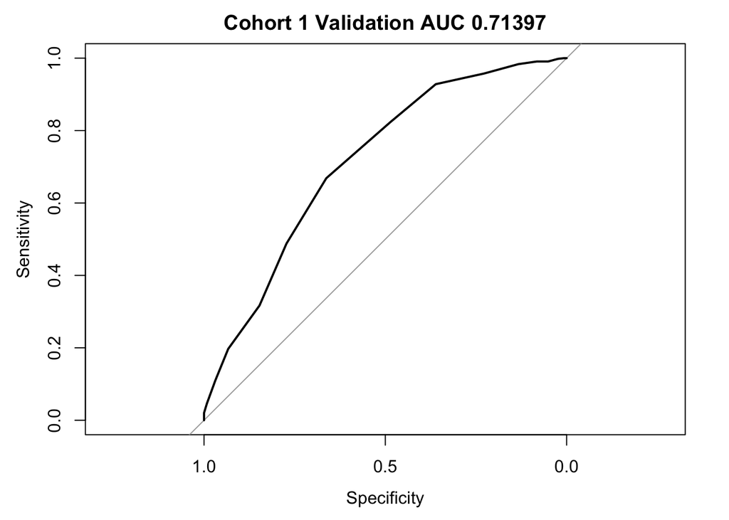

```r
plot(rf.cohort1.ROC, main = paste("Cohort 1 Validation AUC", round(rf.cohort1.ROC$auc, 5)))
```

The reasons why this model failed to identify ABC at all could be: 1) The model learned the training cohort 2 very well but fail to generalise to Cohort 1 2) Cohort 1 and Cohort 2 might have been processed differently. This could lead to a big difference in the range of the expression values in both cohorts, therefore the threshold set by random forest was not able to detect ABC samples. The differences could due to data have not been normalised or caused by technical batch effects from the sequencing process. 3) Cohort 1 has larger sample size (798 samples) which has more diverse dataset and greater heterogeneity than the smaller training Cohort (350 samples) making the accurate classification more challenging.

To check why the optimal model failed to predict ABC samples completely in Cohort 1, I want to check the range of expression values of two cohorts to see if they are very different.

```r
# Check expression values of cohort 2 training data
summary(exprs(train_cohort2)[1:5,1:5])
```

```
##    GSM274895       GSM274896       GSM274898       GSM274899
##  Min.   :3.186   Min.   :3.433   Min.   :4.372   Min.   : 2.787
##  1st Qu.:6.508   1st Qu.:7.277   1st Qu.:5.960   1st Qu.: 7.232
##  Median :6.652   Median :7.436   Median :7.494   Median : 7.321
##  Mean   :6.794   Mean   :7.461   Mean   :7.129   Mean   : 6.969
##  3rd Qu.:8.621   3rd Qu.:9.349   3rd Qu.:8.112   3rd Qu.: 7.471
##  Max.   :9.002   Max.   :9.809   Max.   :9.707   Max.   :10.036
##    GSM274902
##  Min.   :2.848
##  1st Qu.:5.340
##  Median :6.274
##  Mean   :6.315
##  3rd Qu.:7.468
##  Max.   :9.646
```

```r
# Check expression values of validation cohort 1
summary(exprs(cohort_1)[1:5,1:5])
```

```
##     Sample1         Sample2          Sample3          Sample4
##  Min.   : 8.49   Min.   : 9.108   Min.   : 9.014   Min.   :10.65
##  1st Qu.:13.10   1st Qu.:13.480   1st Qu.:13.005   1st Qu.:10.70
##  Median :13.75   Median :14.459   Median :13.419   Median :14.57
##  Mean   :12.89   Mean   :13.282   Mean   :13.006   Mean   :13.08
##  3rd Qu.:14.08   3rd Qu.:14.465   3rd Qu.:14.377   3rd Qu.:14.70
##  Max.   :15.02   Max.   :14.899   Max.   :15.216   Max.   :14.77
##     Sample5
##  Min.   :10.26
##  1st Qu.:13.05
##  Median :14.16
##  Mean   :13.37
##  3rd Qu.:14.47
##  Max.   :14.89
```

As shown in the summary table of expression values of both cohorts, it is clear that the min-max values for cohort 2 training set were between 2 - 10, whereas the min-max values for cohort 1 were between 8 - 15. This could be the reason why the model learned from cohort 2 was inappropriate for cohort 1 data. To overcome this, data normalisation before prediction would likely to improve the performance.